# Analiza retelelor in R

Nicula Florin (Gr 406)

Orosanu Claudiu (Gr 405)

17 December 2018

# **Introducere**

Instalarea resurselor necesare

```r
    library(devtools)
   install_github("DougLuke/UserNetR")
```

# **Analizarea si gestionarea datelor dintr-o retea**

## **Analizarea unei retele**

#### **Preparea datelor**

Pachetul ‘statnet’ va fi folosit pentru analizarea retelei Moreno. Moreno este o retea ce modeleaza relatiile de prietenie dintre copii de clasa a 4 a.

```r
library(statnet)
library(UserNetR)
data(Moreno)
```

#### **Simpla vizualizare a datelor**

Pentru a vizuliza o retea simpla m crea o retea care va arata conexiunile dintre membrii acestia bazata pe sex-ul lor

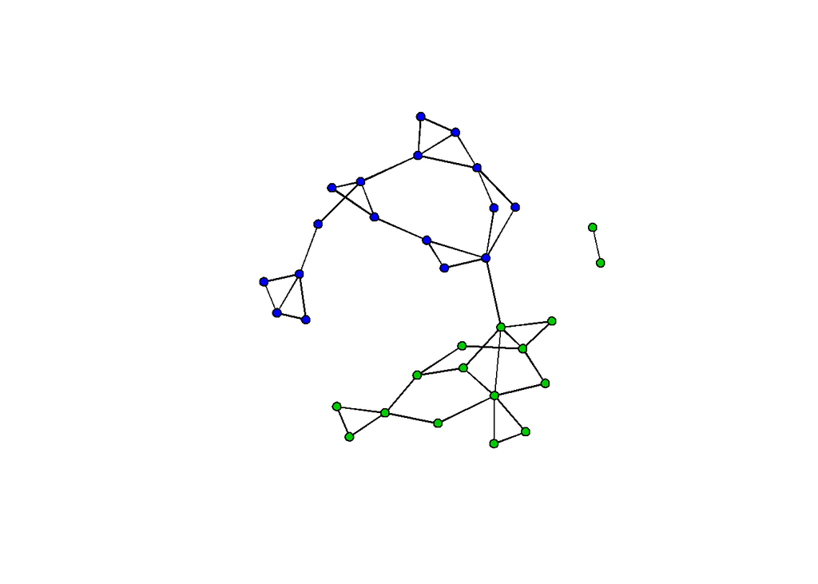

```r
gender <- Moreno %v% "gender"
plot(Moreno, vertex.col = gender + 2, vertex.cex = 1.2)
```

#### **Descrierea functiilor de baza**

Determinarea dimensiunii retelei

```r
network.size(Moreno)
```

```
## [1] 33
```

Pentru a afla mai multe informatii desprea retea putem folosi functia ‘summary’.Setand proprietatea print.adj cu fals oprim afisarea informatiilor despre adiacente

```r
summary(Moreno, print.adj = FALSE)
```

```
## Network attributes:
##   vertices = 33
##   directed = FALSE
##   hyper = FALSE
##   loops = FALSE
##   multiple = FALSE
##   bipartite = FALSE
##  total edges = 46
##    missing edges = 0
##    non-missing edges = 46
##  density = 0.08712121
##
## Vertex attributes:
##
##  gender:
##    numeric valued attribute
##    attribute summary:
##    Min. 1st Qu.  Median    Mean 3rd Qu.    Max.
##   1.000   1.000   2.000   1.515   2.000   2.000
##   vertex.names:
##    character valued attribute
##    33 valid vertex names
##
## No edge attributes
```

Densitatea este procentul de legturi care exista in toata reteaua in raport cu numarul maxim de legaturi care pot exista.Formula cu care se caluleaza densitatea unei retele este: L/(k*(k-1)). L numarul de legaturi existente, k - numarul de noduri. Pentru un graf neorientat numarul de legaturi posibile este la jumatate, astfel se optine urmatoare formula pentru densitate: (2*L)/(k*(k-1)). pentru a calcula densitatea avem metoda ‘gden’.

```r
den_hand <- 2*46/(33*32)
den_hand
```

```
## [1] 0.08712121
```

```r
gden(Moreno)
```

```
## [1] 0.08712121
```

O retea poate fi impartita in mai multe grupe(componente), care sunt alcatuite in R pe baza conexiunii dintre noduri.

```r
components(Moreno)
```

[output not shown]

```
## [1] 2
```

Pe langa dimensiunea generala a unei retele, o caracteristica mai importanta este faptul cat de compacta este o retea. Aceasta caracteristica este data de diametrul retlei. Diametrul este dat de calea cea mai lunga dintre dintre caile cele mai scurte care conecteaza nodurile retelei. Asta inseamna ca diametrul relfecta cazul cel mai rau pentru a transmite date de-a lungul retelei. Extragem cea mai mare componenta din reteau Moreno(care contine 31 de noduri conectate) intr-o noua matrice. Caile cele mai scurte sunt calculate de functia ‘geodist()’. Maximul cailor cele mai scurte este extras’#obtinandu-se diametrul retelei.

```r
lgc <- component.largest(Moreno,result="graph")
```

[output not shown]

```r
gd <- geodist(lgc)
max(gd$gdist)
```

```
## [1] 11
```

#### **Coeficientul de clusterizare**

Coeficientul de clusterizare este dat de transitivitatearetelei, adica procentul de triunghiuri create intre nodurileretelei. Transitivitatea este calculata de functia ‘gtrans’.

```r
gtrans(Moreno,mode="graph")
```

```
## [1] 0.2857143
```

## **Gestionarea datelor dintr-o retea**

#### **Structuri de date pentru o retea**

In majoritatea cazurilor datele sunt stocate sub forma unor dreptunghiri care contin randuri cu valorile individuale ale fiecarei coloane. Din cauza ca retele contin tipuri de relatii complicate de date necesota o structura de stocare diferita, cum ar fi un graf in care informatia este o relatie intre mai multi membrii ai retelei. O alta modalitate de a descrie datele din retea este de a le aranja intr-o matrice. Acest tip de matrice se numeste’sociomatrix’, in care gasim valori doar de 0 si 1 (1 reprezantand existenta legaturi intre doua noduri, iar 0 opusul). Aceasta matrice o un mare dezavantaj deoarece pe masura ce reteau creste valorile de 1 vor fi din ce in ce mai rare. ‘Edge lists’ sunt liste in care contin doua coloane, prima coloana cotine sursa muchiei retelei, iar cea de a doua contine destinatia. Acest lucru face ca listele care contin muchii sa fie alese in detrimentul ‘sociomatrix’ cand vine vorba de retele mari.Obiectele reprezinta un alt mod de a stoca date despre o retea cand vine vorba de date complexe. Acestea pot contine panala 5 tipuri diferite de date: noduri(lista nodurilor din retea), legaturi (lista legaturilor din retea), atributele nodurilor, atributele legaturilor si metadata (contine informatii suplimentare despre retea).

#### **Creare si gestionarea obiectelor intr-o retea**

Pentru a crea o un obiect al unei retele folosim functia ‘network()’, dar mai intai trebui creata o matrice de adiacenta

```r
netmat1 <- rbind(c(0,1,1,0,0),
                 c(0,0,1,1,0),
                 c(0,1,0,0,0),
                 c(0,0,0,0,0),
                 c(0,0,1,0,0))
rownames(netmat1) <- c("A","B","C","D","E")
colnames(netmat1) <- c("A","B","C","D","E")
net1 <- network(netmat1,matrix.type="adjacency")
class(net1)
```

```
## [1] "network"
```

```r
summary(net1)
```

```
## Network attributes:
##   vertices = 5
##   directed = TRUE
##   hyper = FALSE
##   loops = FALSE
##   multiple = FALSE
##   bipartite = FALSE
##  total edges = 6
##    missing edges = 0
##    non-missing edges = 6
##  density = 0.3
##
## Vertex attributes:
##   vertex.names:
##    character valued attribute
##    5 valid vertex names
##
## No edge attributes
##
## Network adjacency matrix:
##   A B C D E
## A 0 1 1 0 0
## B 0 0 1 1 0
## C 0 1 0 0 0
## D 0 0 0 0 0
## E 0 0 1 0 0
```

Vizualizarea retelei noi create:

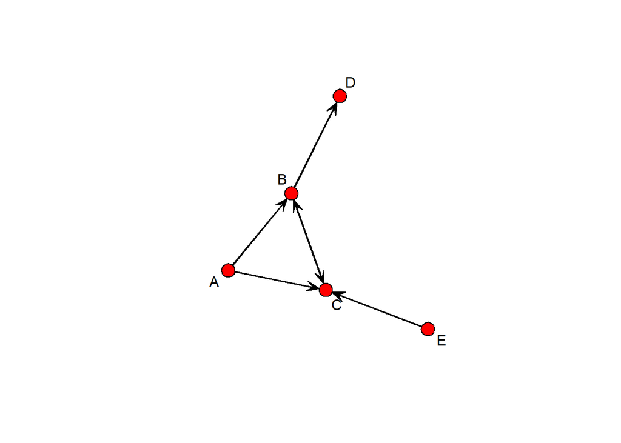

```r
gplot(net1, vertex.col = 2, displaylabels = TRUE)
```

Aceasi retea poate fi creata cu urmatorul cod:

```r
netmat2 <- rbind(c(1,2),
                 c(1,3),
                 c(2,3),
                 c(2,4),
                 c(3,2),
                 c(5,3))
net2 <- network(netmat2,matrix.type="edgelist")
network.vertex.names(net2) <- c("A","B","C","D","E")
summary(net2)
```

```
## Network attributes:
##   vertices = 5
##   directed = TRUE
##   hyper = FALSE
##   loops = FALSE
##   multiple = FALSE
##   bipartite = FALSE
##  total edges = 6
##    missing edges = 0
##    non-missing edges = 6
##  density = 0.3
##
## Vertex attributes:
##   vertex.names:
##    character valued attribute
##    5 valid vertex names
##
## No edge attributes
##
## Network adjacency matrix:
##   A B C D E
## A 0 1 1 0 0
## B 0 0 1 1 0
## C 0 1 0 0 0
## D 0 0 0 0 0
## E 0 0 1 0 0
```

In libraria ‘statnet’ contine si functii prin care o retea poate fi inversate in alte tipuri de date

```r
as.sociomatrix(net1)
```

```
##   A B C D E
## A 0 1 1 0 0
## B 0 0 1 1 0
## C 0 1 0 0 0
## D 0 0 0 0 0
## E 0 0 1 0 0
```

```r
class(as.sociomatrix(net1))
```

```
## [1] "matrix"
```

```r
all(as.matrix(net1) == as.sociomatrix(net1))
```

```
## [1] TRUE
```

```r
as.matrix(net1,matrix.type = "edgelist")
```

```
##      [,1] [,2]
## [1,]    1    2
## [2,]    3    2
## [3,]    1    3
## [4,]    2    3
## [5,]    5    3
## [6,]    2    4
## attr(,"n")
## [1] 5
## attr(,"vnames")
## [1] "A" "B" "C" "D" "E"
```

-setam atribute(sex-ul membrilor) pentru nodurile retelei:

```r
set.vertex.attribute(net1, "gender", c("F", "F", "M", "F", "M"))
```

-vom seta un vector numeric ca si atribut

```r
net1 %v% "alldeg" <- degree(net1)
list.vertex.attributes(net1)
```

```
## [1] "alldeg"       "gender"       "na"           "vertex.names"
```

-afisarea atributului ‘gender’

```r
get.vertex.attribute(net1, "gender")
```

```
## [1] "F" "F" "M" "F" "M"
```

```r
net1 %v% "alldeg"
```

```
## [1] 2 4 4 1 1
```

-setam un numar ales aleator fiecarei muchii din retea si afisam aceasta informatie

```r
list.edge.attributes(net1)
```

```
## [1] "na"
```

```r
set.edge.attribute(net1,"rndval",
                   runif(network.size(net1),0,1))
list.edge.attributes(net1)
```

```
## [1] "na"     "rndval"
```

```r
summary(net1 %e% "rndval")
```

```
##    Min. 1st Qu.  Median    Mean 3rd Qu.    Max.
##  0.1525  0.2473  0.3809  0.3482  0.4372  0.5161
```

```r
summary(get.edge.attribute(net1,"rndval"))
```

```
##    Min. 1st Qu.  Median    Mean 3rd Qu.    Max.
##  0.1525  0.2473  0.3809  0.3482  0.4372  0.5161
```

Cream o matrice de adiacenta in care fiecare muchie reprezinta un nivel de ‘like’(0,1,2,3) intre mebrii retelei:

```r
netval1 <- rbind(c(0,2,3,0,0),
                 c(0,0,3,1,0),
                 c(0,1,0,0,0),
                 c(0,0,0,0,0),
                 c(0,0,2,0,0))
netval1 <- network(netval1,matrix.type="adjacency",
                   ignore.eval=FALSE,names.eval="like")
network.vertex.names(netval1) <- c("A","B","C","D","E")
list.edge.attributes(netval1)
```

```
## [1] "like" "na"
```

```r
## [1] "like" "na"
get.edge.attribute(netval1, "like")
```

```
## [1] 2 1 3 3 2 1
```

Afisarea matricei

```r
as.sociomatrix(netval1)
```

```
##   A B C D E
## A 0 1 1 0 0
## B 0 0 1 1 0
## C 0 1 0 0 0
## D 0 0 0 0 0
## E 0 0 1 0 0
```

```r
as.sociomatrix(netval1,"like")
```

```
##   A B C D E
## A 0 2 3 0 0
## B 0 0 3 1 0
## C 0 1 0 0 0
## D 0 0 0 0 0
## E 0 0 2 0 0
```

Libraria ‘igraph’ este folosita pentru accesa informatii despre retea, asemanator cu libraria ‘network’.

```r
detach(package:statnet)
library(igraph)
```

Cream un graf folosind o matrice de adiacenta, unde D indica un graf orientat, N indica faptul ca nodurile au nume. De asemenea avem numarul de noduri (5) dar si numarul de muchii (6)

```r
inet1 <- graph.adjacency(netmat1)
class(inet1)
```

```
## [1] "igraph"
```

```r
summary(inet1)
```

```
## IGRAPH 8339981 DN-- 5 6 --
## + attr: name (v/c)
```

```r
inet2 <- graph.edgelist(netmat2)
summary(inet2)
```

```
## IGRAPH 833b1db D--- 5 6 --
```

Pentru a asigura posibilitatea de folosi functii din ‘statnet’ pe date din obiectele retelelor care au fost construite cu ‘igraph’ sau vice-versa, folosim libraria ‘intergraph’

```r
library(intergraph)
class(net1)
```

```
## [1] "network"
```

```r
net1igraph <- asIgraph(net1)
class(net1igraph)
```

```
## [1] "igraph"
```

#### **Importarea datelor intr-o retea**

Cream o lista cu muchii pe care o salvam intr-un fisier CSV dupa care citim din fisier si il transformam intr-un obiect

```r
detach("package:igraph", unload=TRUE)
library(statnet)
```

```r
netmat3 <- rbind(c("A","B"),
                 c("A","C"),
                 c("B","C"),
                 c("B","D"),
                 c("C","B"),
                 c("E","C"))
net.df <- data.frame(netmat3)
net.df
```

```
##   X1 X2
## 1  A  B
## 2  A  C
## 3  B  C
## 4  B  D
## 5  C  B
## 6  E  C
```

```r
write.csv(net.df, file = "MyData.csv",
          row.names = FALSE)
net.edge <- read.csv(file="MyData.csv")
net_import <- network(net.edge,
                      matrix.type="edgelist")
summary(net_import)
```

```
## Network attributes:
##   vertices = 5
##   directed = TRUE
##   hyper = FALSE
##   loops = FALSE
##   multiple = FALSE
##   bipartite = FALSE
##  total edges = 6
##    missing edges = 0
##    non-missing edges = 6
##  density = 0.3
##
## Vertex attributes:
##   vertex.names:
##    character valued attribute
##    5 valid vertex names
##
## No edge attributes
##
## Network adjacency matrix:
##   A B C D E
## A 0 1 1 0 0
## B 0 0 1 1 0
## C 0 1 0 0 0
## D 0 0 0 0 0
## E 0 0 1 0 0
```

```r
gden(net_import)
```

```
## [1] 0.3
```

#### **Operatii pe datele dintr-o retea**

##### **Filtrarea retelelor**

Intr-un obiect al retelei putem gasi caracteristici ale nodurilor salvate ca atribute ale muchiilor. Aceasta informatie poate fi folosita pentru a selecta sub retele pentru analiza get.inducedSubgraph() este o functie care returneaza un nou obiect al retelei care este bazat pe criteriul de filtrare

```r
n1F <- get.inducedSubgraph(net1,
                           which(net1 %v% "gender" == "F"))
n1F[,]
```

```
##   A B D
## A 0 1 0
## B 0 0 1
## D 0 0 0
```

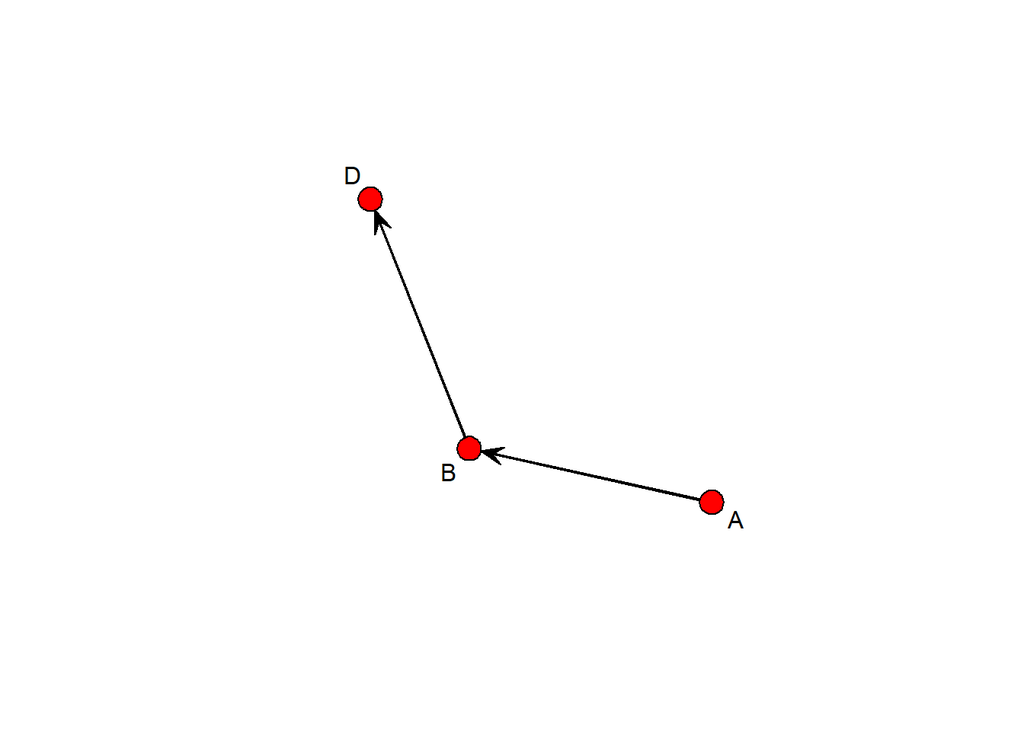

```r
gplot(n1F,displaylabels=TRUE)
```

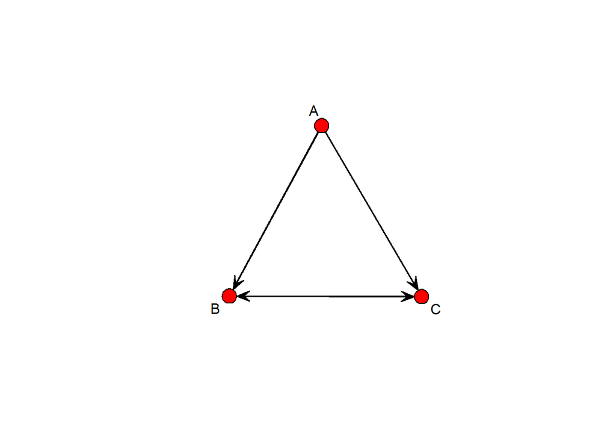

```r
deg <- net1 %v% "alldeg"
n2 <- net1 %s% which(deg > 1)
gplot(n2,displaylabels=TRUE)
```

Folosind setul de date ‘ICTS’ din pachetul ‘UserNetR’, a carei retele contine date despre oameni de stiinta. Utilizand functia ‘isolates’ putem detecta numarul de noduri izolate.

```r
data(ICTS_G10)
gden(ICTS_G10)
```

```
## [1] 0.01120566
```

```r
length(isolates(ICTS_G10))
```

```
## [1] 96
```

Stergerea acestora se face utilizand functia ‘delete.vertices’ care nu returneaza un obiect ci opereaza direct pe setul de date pe care il primeste. Din acest moriv e mai sigur la copiem datele intr-o variabila

```r
n3 <- ICTS_G10
delete.vertices(n3,isolates(n3))
gden(n3)
```

```
## [1] 0.01728876
```

```r
length(isolates(n3))
```

```
## [1] 0
```

Pentru filtrarea bazata pe valorile muchiilor folosim o alta retea numita ‘DHHS’ care contine date despre experti in controlul tutunului care lucreza in 11 agentii diferite. Dupa cum se poate observa aceasta retea este foarte densa si greu de interpretat.

```r
data(DHHS)
d <- DHHS
gden(d)
```

```
## [1] 0.312369
```

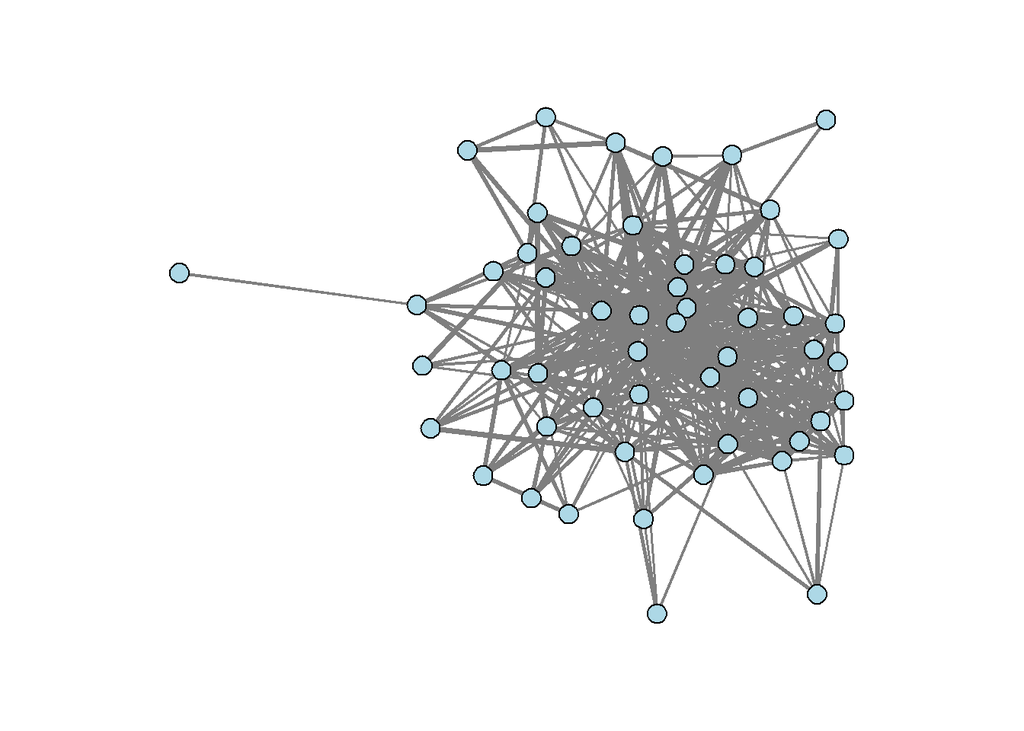

```r
op <- par(mar = rep(0, 4))
gplot(d,gmode="graph",
      edge.lwd=d %e%'collab',edge.col="grey50",vertex.col="lightblue", vertex.cex=1.0,vertex.sides=20)
```

```r
par(op)
```

Pentru a avea o imagine clara asupra retelei o vom filtra dupa valoriile muchiilor. Primul lucru pe care il vom face este sa extragem primii 6 membrii din retea pentru a determina legaturile din acestia.

```r
as.sociomatrix(d)[1:6,1:6]
```

```
##        ACF-1 ACF-2 AHRQ-1 AHRQ-2 AHRQ-3 AHRQ-4
## ACF-1      0     1      0      0      0      0
## ACF-2      1     0      0      0      0      0
## AHRQ-1     0     0      0      1      1      1
## AHRQ-2     0     0      1      0      1      1
## AHRQ-3     0     0      1      1      0      1
## AHRQ-4     0     0      1      1      1      0
```

```r
list.edge.attributes(d)
```

```
## [1] "collab" "na"
```

```r
as.sociomatrix(d,attrname="collab")[1:6,1:6]
```

```
##        ACF-1 ACF-2 AHRQ-1 AHRQ-2 AHRQ-3 AHRQ-4
## ACF-1      0     1      0      0      0      0
## ACF-2      1     0      0      0      0      0
## AHRQ-1     0     0      0      3      3      3
## AHRQ-2     0     0      3      0      3      2
## AHRQ-3     0     0      3      3      0      3
## AHRQ-4     0     0      3      2      3      0
```

Vom observa ca exista 447 de legaturi in acest set de date:

```r
table(d %e%"collab")
```

```
##
##   1   2   3   4
## 163 111  94  79
```

Dintre care 163 reprezinta schimbul de informatii neoficiale, 111 sunt legaturi informale, 94 sunt legaturi formale pe un singur proiect iar restul de 79 sunt legaturi care reprezinta legaturi intre membrii care au lucrat impreuna pe mai multe proiecte. Vom extrage intr-o matrice toate colaborarile dupa care vom filtra legaturile care ne intereseaza, adica vo inlocui legaturile cu valoarea 1 sau 2 cu 0.

```r
d.val <- as.sociomatrix(d,attrname="collab")
d.val[d.val < 3] <- 0
d.filt <- as.network(d.val, directed=FALSE,
                     matrix.type="a",ignore.eval=FALSE,
                     names.eval="collab")
summary(d.filt,print.adj=FALSE)
```

```
## Network attributes:
##   vertices = 54
##   directed = FALSE
##   hyper = FALSE
##   loops = FALSE
##   multiple = FALSE
##   bipartite = FALSE
##  total edges = 173
##    missing edges = 0
##    non-missing edges = 173
##  density = 0.1208945
##
## Vertex attributes:
##   vertex.names:
##    character valued attribute
##    54 valid vertex names
##
## Edge attributes:
##
##  collab:
##    numeric valued attribute
##    attribute summary:
##    Min. 1st Qu.  Median    Mean 3rd Qu.    Max.
##   3.000   3.000   3.000   3.457   4.000   4.000
```

```r
gden(d.filt)
```

```
## [1] 0.1208945
```

Vom observa ca doar 173 legaturi corespund cu nivelul 3 si 4 de colaborare. Acum putem observa o retea mai mica:

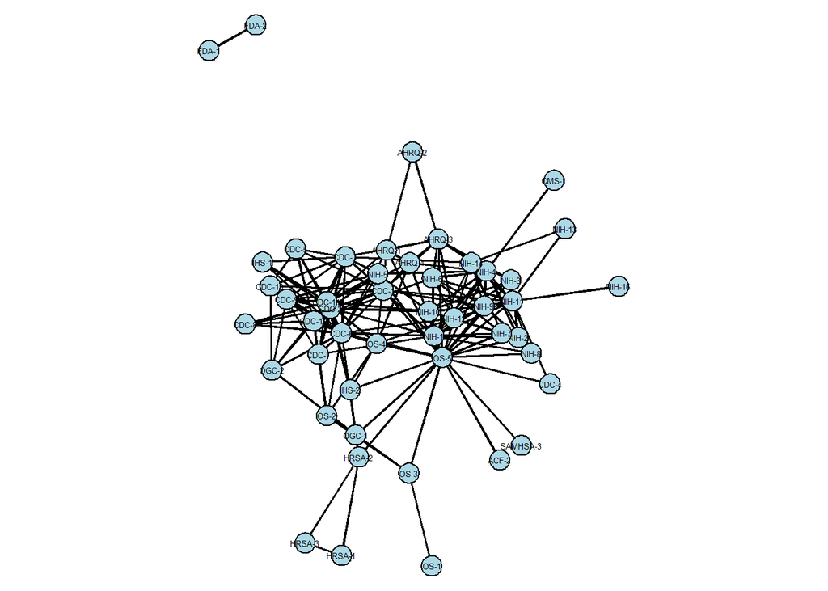

```r
op <- par(mar = rep(0, 4))
gplot(d.filt,gmode="graph",displaylabels=TRUE,
      vertex.col="lightblue",vertex.cex=1.3,
      label.cex=0.4,label.pos=5, displayisolates=FALSE)
```

```r
par(op)
```

Transformarea unei retele orientate la o retea neorientata in R putem folosi functia ‘symmetrize()’. Intr-o matrice de tip ‘sociomatrix’ daca datele sunt simetrice in jurul diagonalei indica faptul ca legaturile sunt neorientate. Utilizarea functie este destul de simpla cu exceptia faptului ca returneaza o matrice de tipul ‘sociomatrix’ sau o lista de muchii. Putem gestiona acest lucru trebuie ca rezultatul sa fie transformat intr-un obiect. Parametrul ‘rule’ ne permite sa alegeme modul in care simetrizam legaturile. Valoare ‘weak’ a cestui parametru corespunde operatorului logic sau (OR) unde noile legaturile sunt create intre noduri indiferent de orientarea precendeta a acestora. In schimb valoare ‘strong’ corespunde cu operatorul logic si (AND).

```r
net1mat <- symmetrize(net1,rule="weak")
net1mat
```

```
##      [,1] [,2] [,3] [,4] [,5]
## [1,]    0    1    1    0    0
## [2,]    1    0    1    1    0
## [3,]    1    1    0    0    1
## [4,]    0    1    0    0    0
## [5,]    0    0    1    0    0
```

```r
net1symm <- network(net1mat,matrix.type="adjacency")
network.vertex.names(net1symm) <- c("A","B","C","D","E")
summary(net1symm)
```

```
## Network attributes:
##   vertices = 5
##   directed = TRUE
##   hyper = FALSE
##   loops = FALSE
##   multiple = FALSE
##   bipartite = FALSE
##  total edges = 10
##    missing edges = 0
##    non-missing edges = 10
##  density = 0.5
##
## Vertex attributes:
##   vertex.names:
##    character valued attribute
##    5 valid vertex names
##
## No edge attributes
##
## Network adjacency matrix:
##   A B C D E
## A 0 1 1 0 0
## B 1 0 1 1 0
## C 1 1 0 0 1
## D 0 1 0 0 0
## E 0 0 1 0 0
```

# **Vizualizarea retelelor**

## **1. Tehnici de plotare si layout**

Reprezentarea vizuala a retelelor este o provocare. Numarul de moduri in care o retea poate fi reprezentata vizual este practic infinit. Un grafic sugestiv va transmite informatiile importante despre retea, cum ar fi structura generala, locatia actorilor importanti din retea, prezenta unor subgrupuri distinctive. De asemenea, informatia irelevanta trebuie sa fie cat mai putina.

```r
library(statnet)
library(UserNetR)
data(Moreno)
```

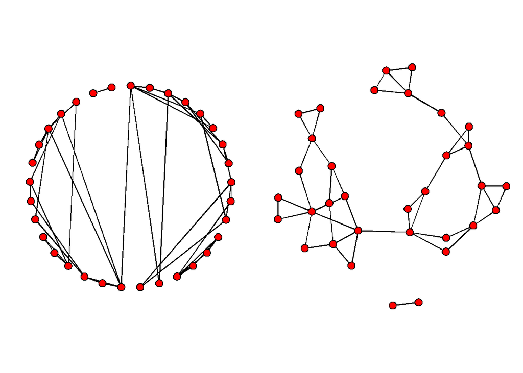

```r
op <- par(mar = rep(0, 4),mfrow=c(1,2))
plot(Moreno,mode="circle",vertex.cex=1.5)
plot(Moreno,mode="fruchtermanreingold",vertex.cex=1.5)
```

```r
par(op)
```

Moreno este o retea ce modeleaza relatiile de prietenie dintre copii de clasa a 4 a.

La prima vedere, cele doua grafice par a fi foarte diferite. Totusi, ele sunt construite pe baza aceleiasi retele (Moreno). Se observa aici faptul ca graficul din partea dreapta este mult mai usor de interpretat. Se pot distinge doua componenete separate ale retelei, iar componenta mai mare este si ea impartita la randul ei intre doua componente.

Lungimea muchiilor in aceste grafice nu are nicio insemnatate. Alegerea la intamplare a acestor lungimi poate induce in eroare.

### **Principii estetice in reprezentarea retelelor**

Din cercetarile facute in acest domeniu, au reiesit cateva principii care ajuta la reprezentarea corecta a retelelor.

- Cat mai putine intersectii ale muchiilor
- Simetria nodurilor in retea trebuie sa fie cat mai mare
- Lungimea muchiilor trebuie sa varieze cat mai putin
- Atunci cand doua muchii se intersecteaza, unghiul format trebuie sa fie cat mai mare
- Minimizarea spatiului pentru reprezentarea retelei

Mai multe abordari au aparut in ceea ce priveste reprezentarea automata a unei retele. O varianta populara este urmatoarea: nodurile conectate se “atrag”, in timp ce o forta repulsiva actioneaza intre toate perechile de noduri. Reteaua va oscila pentru un timp, dar la un moment dat se va stabiliza, iar energia din sistem va fi minima.

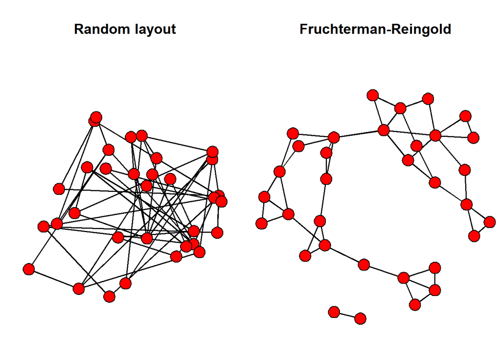

```r
op <- par(mar = c(0,0,4,0),mfrow=c(1,2))
gplot(Moreno,gmode="graph",mode="random",vertex.cex=1.5,main="Random layout")
gplot(Moreno,gmode="graph",mode="fruchtermanreingold",vertex.cex=1.5,main="Fruchterman-Reingold")
```

```r
par(op)
```

Graficul din dreapta este realizat cu algoritmul *Fruchterman-Reingold*, care actioneaza cum am precizat mai sus, facand parte din clasa algoritmilor *force-directed*. Se observa ca toate principiile estetice enumerate mai sus sunt respectate.

Algoritmii *force-directed* sunt iterativi si non-deterministici. Asta inseamna ca graficul rezultat nu va fi identic, la fiecare rulare, insa va fi destul de similar.

### **Algoritmi si metode de plotare**

In libraria *statnet*, exista doua functii prin care se poate realiza un grafic al unei retele: *plot* si *gplot*. Folosing functia *gplot* avem mai multe optiuni de layout, prin argumentul *mode*.

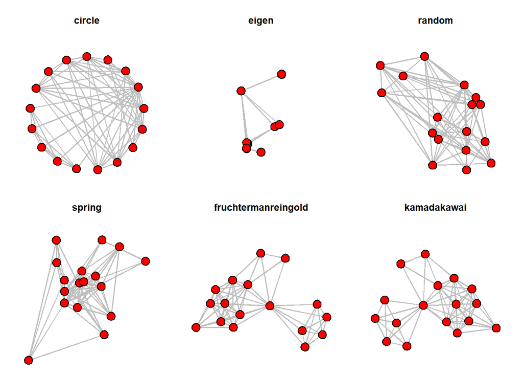

```r
op <- par(mar=c(0,0,4,0),mfrow=c(2,3))

gplot(Bali,gmode="graph",edge.col="grey75",vertex.cex=1.5,mode='circle',main="circle")

gplot(Bali,gmode="graph",edge.col="grey75",vertex.cex=1.5,mode='eigen',main="eigen")

gplot(Bali,gmode="graph",edge.col="grey75",vertex.cex=1.5,mode='random',main="random")

gplot(Bali,gmode="graph",edge.col="grey75",vertex.cex=1.5,mode='spring',main="spring")

gplot(Bali,gmode="graph",edge.col="grey75",vertex.cex=1.5,mode='fruchtermanreingold',main='fruchtermanreingold')

gplot(Bali,gmode="graph",edge.col="grey75",vertex.cex=1.5,mode='kamadakawai',main='kamadakawai')
```

```r
par(op)
```

#### **Control mai ridicat asupra layout-ului**

Variantele de layout prezente in bibliotecile *statnet* si *igraph* functioneaza pe baza unor algoritmi iterativi si non-deterministici. De aceea, graficul va fi diferit de fiecare data cand este realizat. Din fericire, R ne ofera posibilitatea de a specifica coordonatele fiecarui nod.

Parametrul **coord** din functia **plot** este folosit in scopul acesta. El ar trebui sa primeasca o matrice cu doua coloane (X si Y), unde fiecare rand reprezinta coordonatele unui nod. De asemenea, functia **gplot**, atunci cand este apelata, intoarce coordonatele nodurilor, iar acestea pot fi salvate intr-o variabila.

Prima oara, vom plota graficul si vom salva coordonatele nodurilor. Apoi vom modifica coordonatele, “largind” graficul pe directia verticala. Apoi vom compara cele doua grafice, apeland functia *gplot* cu coordonatele precalculate.

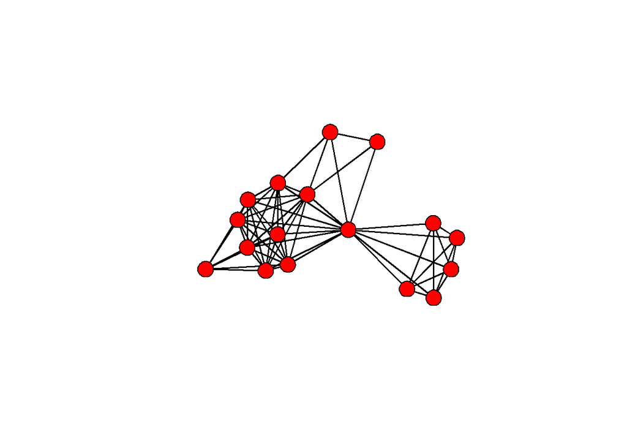

```r
mycoords1 <- gplot(Bali,gmode="graph",vertex.cex=1.5)
```

```r
mycoords1
```

```
##                x          y
##  [1,] -1.5170932 -1.9383437
##  [2,]  0.4281911 -0.0416917
##  [3,] -1.5333516 -3.8556347
##  [4,]  1.1053454 -3.6836667
##  [5,] -1.9753454 -5.2104824
##  [6,] -0.4233073 -2.3667073
##  [7,]  2.1882730 -0.4056986
##  [8,] -2.6656237 -4.3501995
##  [9,] -2.6428510 -2.5670292
## [10,]  4.2892994 -6.2226515
## [11,]  4.9442818 -5.1574806
## [12,]  4.2701058 -3.4433681
## [13,]  5.1605570 -3.9930111
## [14,]  3.2935825 -5.8929363
## [15,] -1.1493225 -4.9838651
## [16,] -4.2210706 -5.1556160
## [17,] -3.0248684 -3.3158555
```

```r
mycoords2 <- mycoords1
mycoords2[,2] <- mycoords1[,2]*1.5
mycoords2
```

```
##                x           y
##  [1,] -1.5170932 -2.90751555
##  [2,]  0.4281911 -0.06253754
##  [3,] -1.5333516 -5.78345202
##  [4,]  1.1053454 -5.52550012
##  [5,] -1.9753454 -7.81572360
##  [6,] -0.4233073 -3.55006091
##  [7,]  2.1882730 -0.60854788
##  [8,] -2.6656237 -6.52529930
##  [9,] -2.6428510 -3.85054373
## [10,]  4.2892994 -9.33397726
## [11,]  4.9442818 -7.73622091
## [12,]  4.2701058 -5.16505213
## [13,]  5.1605570 -5.98951671
## [14,]  3.2935825 -8.83940447
## [15,] -1.1493225 -7.47579768
## [16,] -4.2210706 -7.73342394
## [17,] -3.0248684 -4.97378328
```

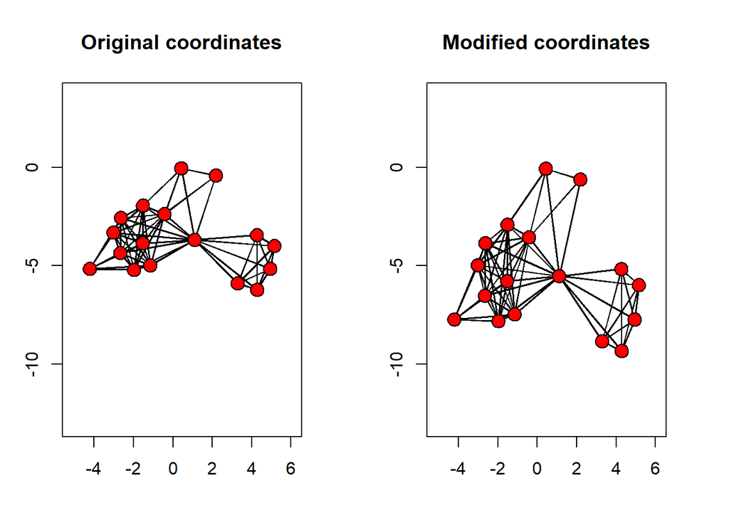

```r
op <- par(mar=c(4,3,4,3),mfrow=c(1,2))

gplot(Bali,gmode="graph",vertex.cex=1.5,
      coord=mycoords1, suppress.axes = FALSE,
      ylim=c(min(mycoords2[,2])-1,max(mycoords2[,2])+1),
      main="Original coordinates")

gplot(Bali,gmode="graph",vertex.cex=1.5,
      coord=mycoords2,suppress.axes = FALSE,
      ylim=c(min(mycoords2[,2])-1,max(mycoords2[,2])+1),
      main="Modified coordinates")
```

```r
par(op)
```

#### **Metode de plotare folosind libraria *igraph***

Libraria **igraph** ne ofera optiuni similare in ceea ce priveste layout-ul graficului. Parametrul **layout** al functiei **plot** este util.

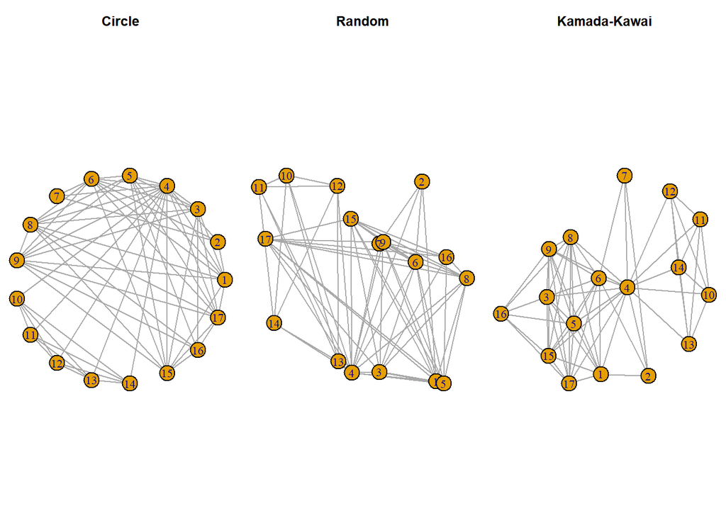

```r
iBali <- asIgraph(Bali)
op <- par(mar=c(0,0,3,0),mfrow=c(1,3))
plot(iBali,layout=layout_in_circle,main="Circle")
plot(iBali,layout=layout_randomly,main="Random")
plot(iBali,layout=layout_with_kk,main="Kamada-Kawai")
```

```r
par(op)
```

## **2. Design sugestiv in realizarea graficelor**

Obiectivul principal al unui design eficace este de a dezvalui trasaturile importante ale unei retele si informatia continuta in aceasta. Pentru atingerea acestui scop, librariile *statnet* si *igraph* ofera control programatic asupra aspectului oricarui element din graficul retelei.

> Excelenta in design-ul grafic presupune transmiterea unui numar cat mai mare de idei intr-un timp cat mai scurt, folosind cat mai putina cerneala si spatiu. - Edward Tufte

Un grafic al unei retele contine o multitudine de elemente (noduri, legaturi) dar si elemente care se regasesc in orice tip de grafic (titluri, legende, etc.). Alegerea unor caracteristici potrivite pentru aceste elemente se face respectand principiile estetice, dar ele difera in functie de “povestea” pe care analistul vrea sa o transmita.

### **Culoarea nodurilor**

Implicit, *statnet* foloseste cercuri de culoare rosie pentru a reprezenta nodurile retelei. Culoarea nodurilor se poate configura prin optiunea **vertex.col** a functiei **gplot**. Optiunea *gmode* este “graph” pentru a nu interpreta graful ca fiind orientat.

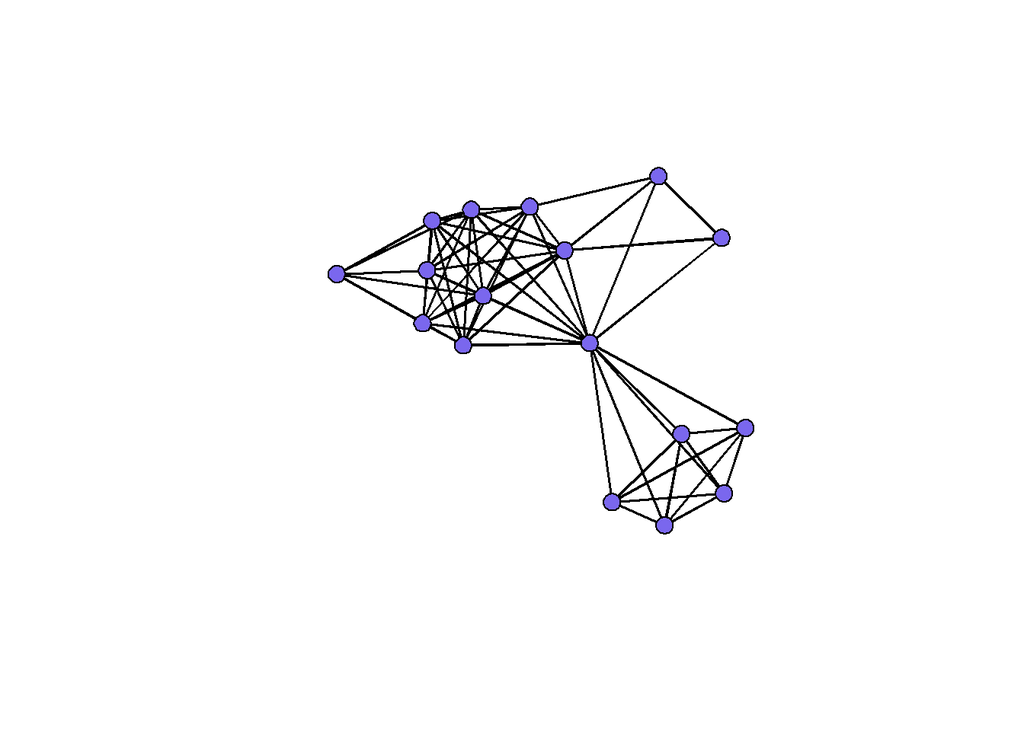

```r
gplot(Bali,vertex.col="slateblue2",gmode="graph")
```

R ofera 657 de culori, care pot fi consultate folosind functia **colors()**. De asemenea, culorile se pot crea cu ajutorul functiei **rgb**, dar pot fi definite si ca stringuri formate din caractere hexazecimale (**#RRGGBB**). Functia **col2rgb** transforma o culoare predefinita (din colors()) intr-un triplet de intensitati.

```r
col2rgb('slateblue2')
```

```
##       [,1]
## red    122
## green  103
## blue   238
```

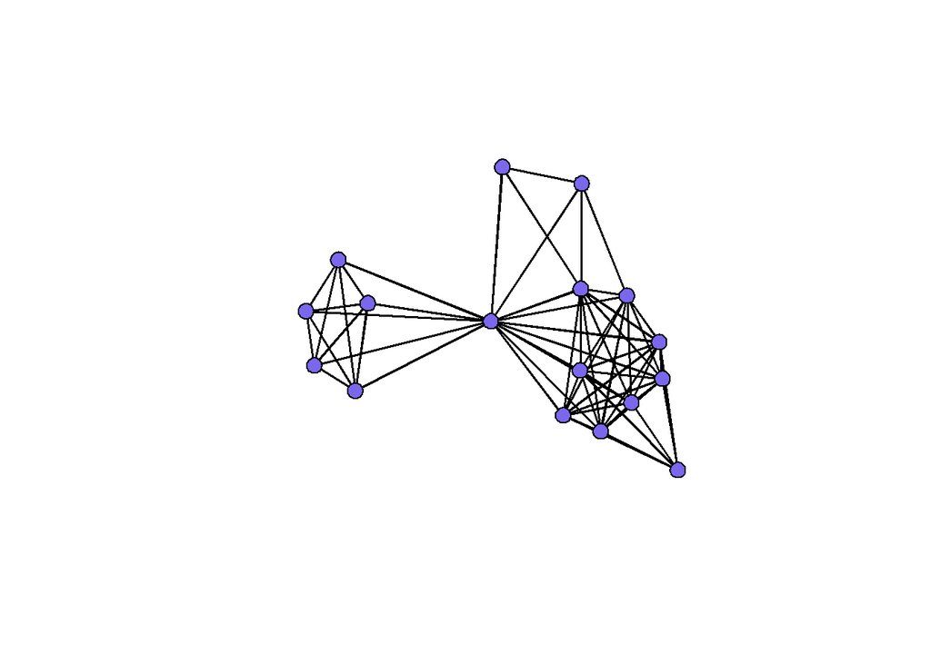

```r
gplot(Bali,vertex.col=rgb(122,103,238,maxColorValue=255),gmode="graph")
```

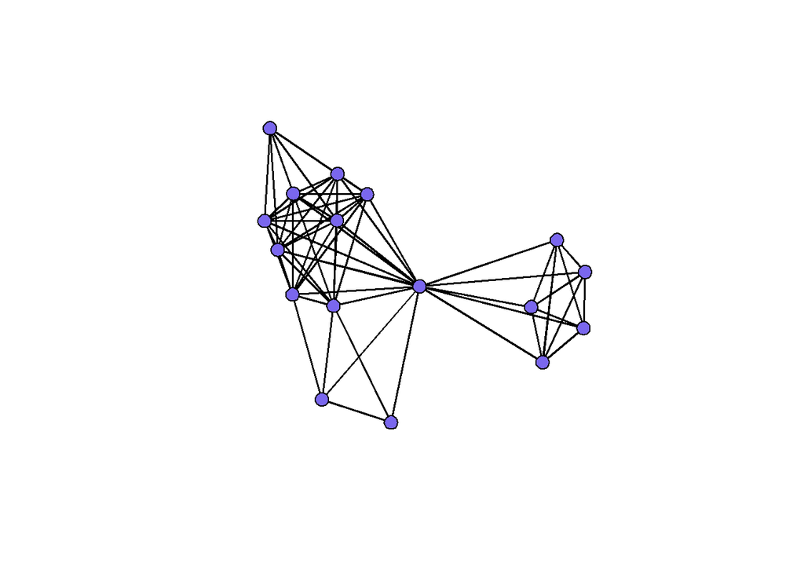

```r
gplot(Bali,vertex.col="#7A67EE",gmode="graph")
```

De asemenea, functia **rgb** mai are si optiunea **alpha** care reprezinta transparenta nodurilor. Intr-un graf cu foarte multe noduri, acestea pot fi greu de distins daca se suprapun unele peste altele. Daca culorile sunt transparente, graficul e mai usor de inteles.

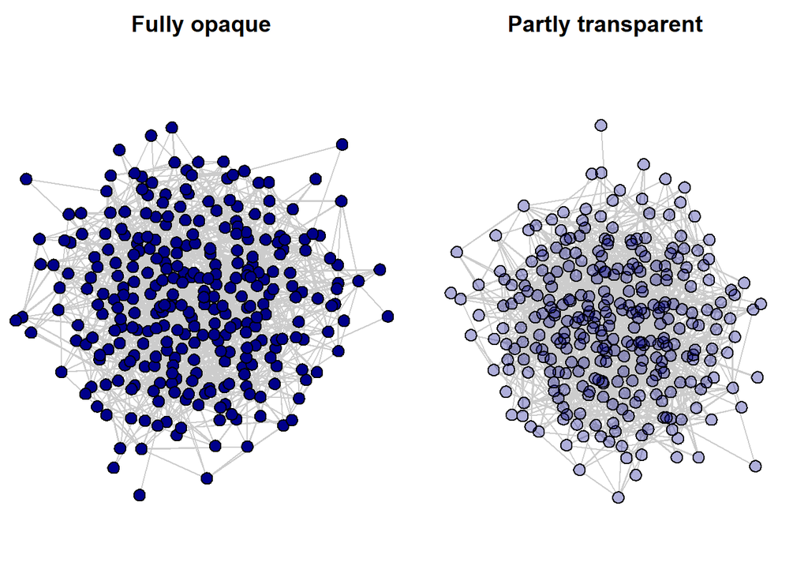

```r
ndum <- rgraph(300,tprob=0.025,mode="graph")

op <- par(mar = c(0,0,2,0),mfrow=c(1,2))

gplot(ndum,gmode="graph",
      vertex.cex=2, vertex.col=rgb(0,0,139,maxColorValue=255),
      edge.col="grey80",edge.lwd=0.5,
      main="Fully opaque")

gplot(ndum,gmode="graph",
      vertex.cex=2,vertex.col=rgb(0,0,139,alpha=80,maxColorValue=255),
      edge.col="grey80",edge.lwd=0.5,
      main="Partly transparent")
```

```r
par(op)
```

In exemplele anterioare, toate nodurile aveau aceeasi culoare. Totusi, culori diferite se pot atribui nodurilor pentru a comunica o caracteristica a acestora, apartenenta la o anumita categorie.

De exemplu, reteaua Bali contine atributul *role* pentru fiecare nod, care reprezinta rolul fiecarui membru in gruparea terorita (BM - bomb maker, CT - command team, etc.). Reprezentarea fiecarui rol cu o culoare diferita poate ilustra mai bine informatia din interiorul retelei.

Acest lucru se realizeaza prin specificarea atributului categoric (*role*, in cazul acesta) al nodurilor pentru optiunea **vertex.col** atunci cand se foloseste functia **plot**.

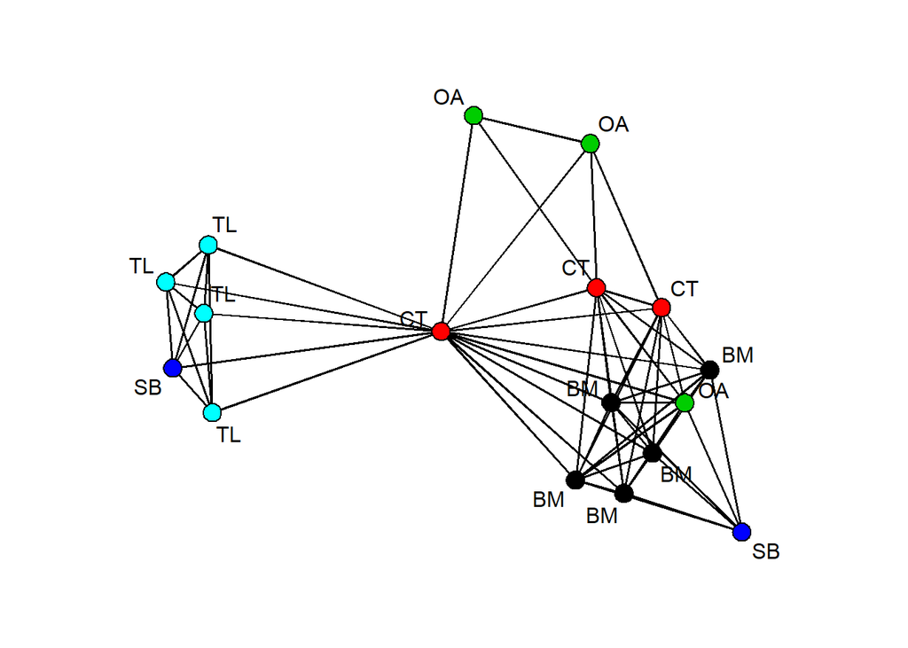

```r
rolelab <- get.vertex.attribute(Bali,"role")
op <- par(mar=c(0,0,0,0))
plot(Bali,usearrows=FALSE,vertex.cex=1.5,label=rolelab,displaylabels=T,vertex.col="role")
```

```r
par(op)
```

Optiunea **label** reprezinta textele asociate fiecarui nod, iar acestea sunt luate din vectorul de roluri.

Graficul este mai usor de interpretat acum, se pot observa mici subgrupuri (TL si BM). Totusi, culorile de mai sus sunt luate implicit din paleta de culori din R.

```r
palette()
```

```
## [1] "black"   "red"     "green3"  "blue"    "cyan"    "magenta" "yellow"
## [8] "gray"
```

Aceasta paleta de culori are cateva dezavantaje. Este limitata la 8 culori iar culorile incluse nu sunt sugestive in realizarea unui grafic. O alternativa mai buna este definirea unei palete de culori custom, cu ajutorul librariei *RColorBrewer*.

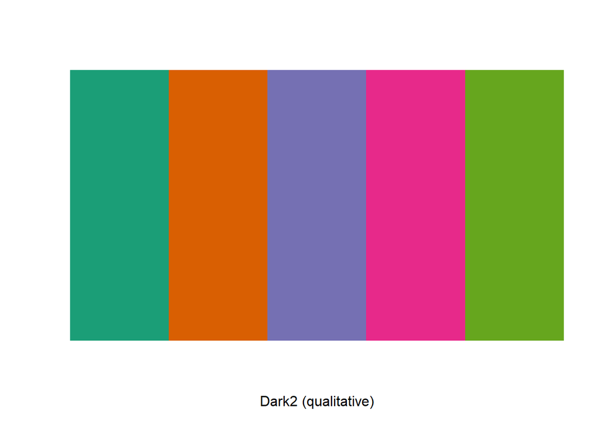

```r
library(RColorBrewer)
display.brewer.pal(5, "Dark2")
```

Acestea sunt 5 culori alese dintr-o paleta mai larga numita *Dark2*. Culorile sunt mai placute decat cele din paleta default. Pentru a crea un grafic folosind aceasta paleta de culori, se procedeaza in felul urmator:

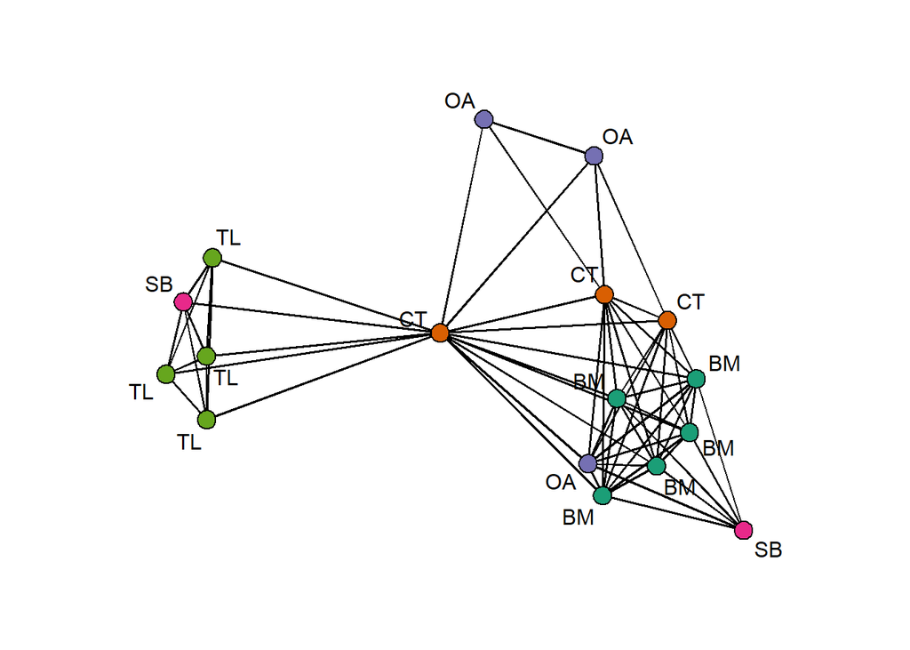

```r
op <- par(mar=c(0,0,0,0))
my_pal <- brewer.pal(5,"Dark2")
rolecat <- as.factor(get.vertex.attribute(Bali,"role"))
plot(Bali,vertex.cex=1.5,label=rolelab,displaylabels=T,vertex.col=my_pal[rolecat])
```

```r
par(op)
```

Pentru a putea folosi atributul *role* acesta trebuie castat intr-un *factor* si apoi pasat functiei **plot**.

### **Forma nodurilor**

Pe langa culoarea nodurilor, putem controla si forma lor. Acest lucru e util atunci cand sunt putine categorii de noduri. De asemenea, este folositor pentru persoanele care nu pot distinge culori. In libraria *statnet*, nodurile sunt practic poligoane, iar singurul lucru configurabil este numarul de laturi (3 - triunghi, 4 - patrat, etc.).

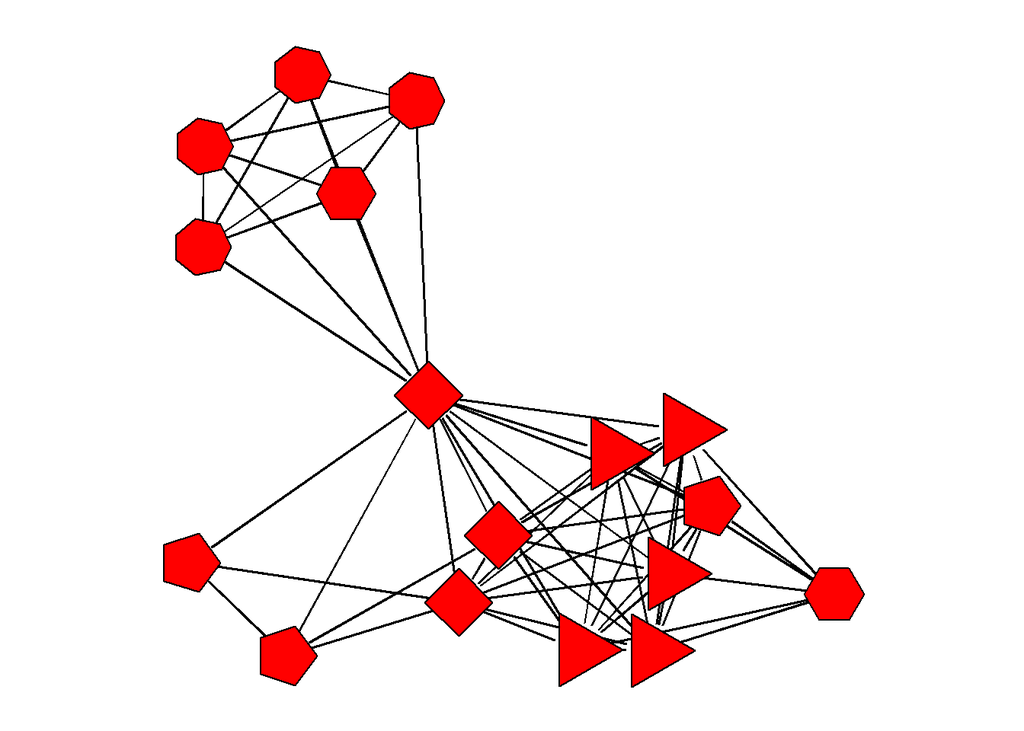

```r
op <- par(mar=c(0,0,0,0))
sidenum <- 3:7
plot(Bali,usearrows=FALSE,vertex.cex=4,displaylabels=F,vertex.sides=sidenum[rolecat])
```

```r
par(op)
```

### **Marimea nodurilor**

Marimea nodurilor este controlata prin optiunea **vertex.cex** a functiilor *gplot* si *plot*.

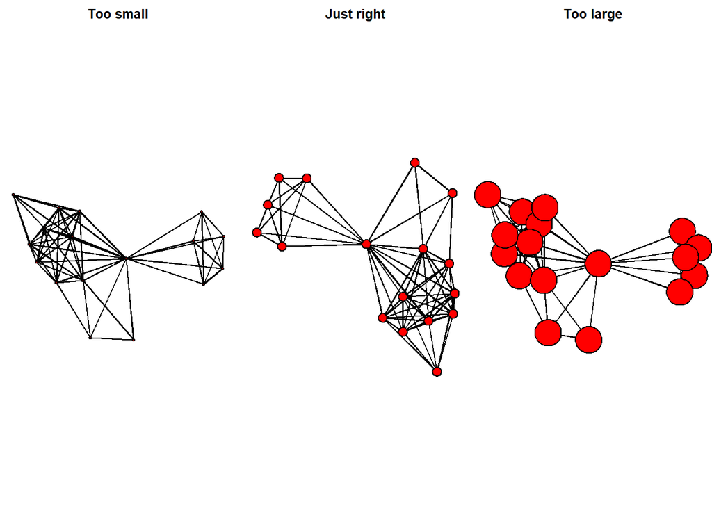

```r
op <- par(mar = c(0,0,2,0),mfrow=c(1,3))
plot(Bali,vertex.cex=0.5,main="Too small")
plot(Bali,vertex.cex=2,main="Just right")
plot(Bali,vertex.cex=6,main="Too large")
```

```r
par(op)
```

Mai interesanta este reprezentarea nodurilor prin **marimi diferite** penru a reliefa o **caracteristica cantitativa**. Cum nodurile din reteaua Bali nu au un atribut cantitativ, vom simula unul. O valoare mai mare a acestui atribut (numar) inseamna ca nodul este mai central. Pentru a masura centralitatea unui nod, ne vom folosi de trei masuri diferite.

```r
deg <- degree(Bali,gmode="graph")
deg
```

```
##  [1]  9  4  9 15  9 10  3  9  9  5  5  5  5  5  9  6  9
```

```r
cls <- closeness(Bali,gmode="graph")
cls
```

```
##  [1] 0.6956522 0.5517241 0.6956522 0.9411765 0.6956522 0.7272727 0.5333333
##  [8] 0.6956522 0.6956522 0.5714286 0.5714286 0.5714286 0.5714286 0.5714286
## [15] 0.6956522 0.4848485 0.6956522
```

```r
bet <- betweenness(Bali,gmode="graph")
bet
```

```
##  [1]  2.3333333  0.3333333  1.6666667 61.1666667  1.6666667  6.1666667
##  [7]  0.0000000  1.6666667  1.6666667  0.0000000  0.0000000  0.0000000
## [13]  0.0000000  0.0000000  1.6666667  0.0000000  1.6666667
```

Vectorii rezultati contin, pentru fiecare nod, o marime relativa. In cazul primului vector **deg** care contine gradul fiecarui nod, valorile sunt prea mari, asa ca vom calcula logaritmul fiecare valori folosind functia **log**.

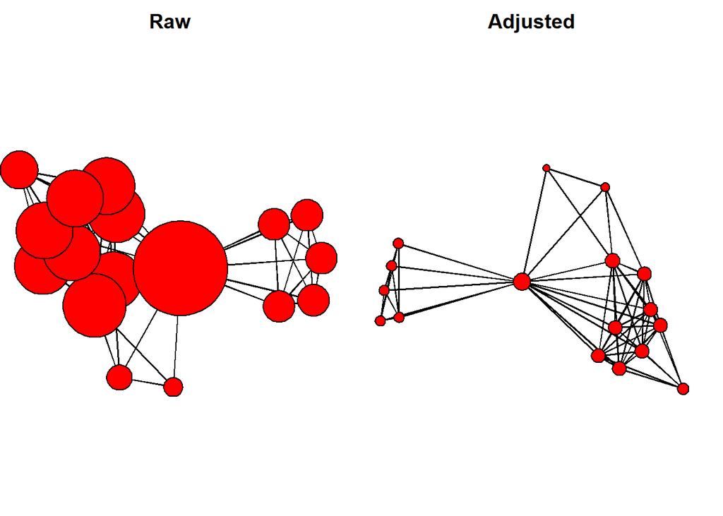

```r
op <- par(mar = c(0,0,2,1),mfrow=c(1,2))
plot(Bali,usearrows=T,vertex.cex=deg,main="Raw")
plot(Bali,usearrows=FALSE,vertex.cex=log(deg),main="Adjusted")
```

```r
par(op)
```

Urmatoarele doua exemple necesita alt tip de ajustari. Pentru vectorul **cls** valorile sunt prea mici, iar nodurile retelelei nu vor fi vizibile. In consecinta, vom inmulti toate valorile cu 4. Pentru vectorul **bet**, unele valori sunt foarte mari, iar altele foarte mici, unele fiind chiar 0. Pentru a obtile marimile potrivite, vom aduna 1 si apoi vom calcula radacina patrata a fiecarui numar.

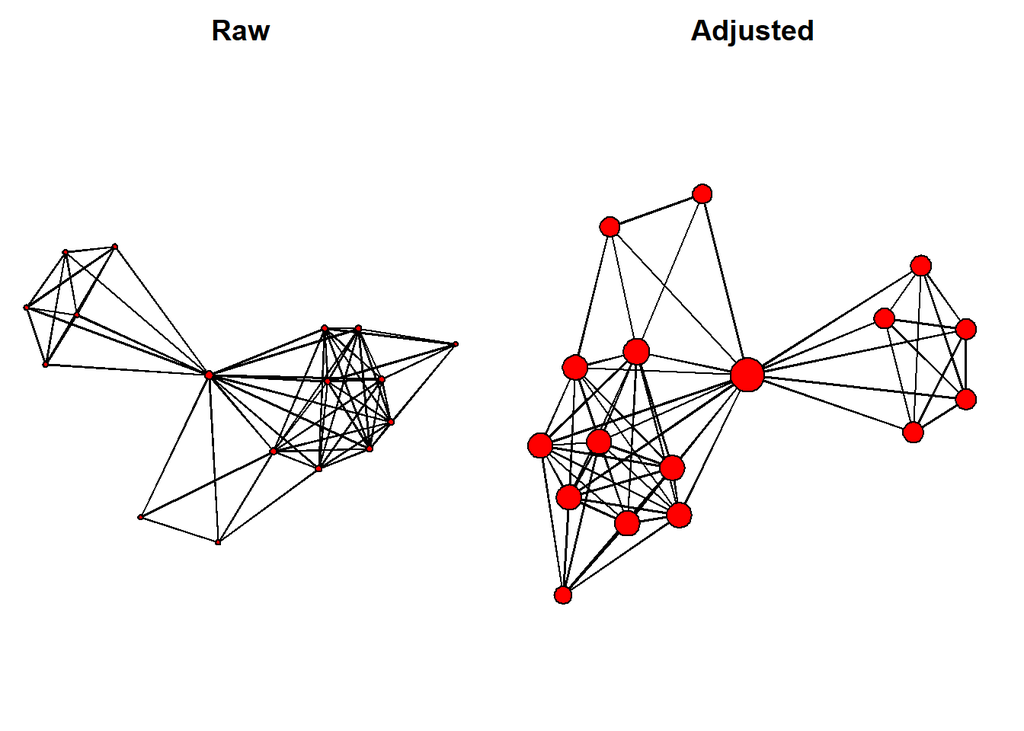

```r
op <- par(mar = c(0,0,2,1),mfrow=c(1,2))
plot(Bali,usearrows=T,vertex.cex=cls,main="Raw")
plot(Bali,usearrows=FALSE,vertex.cex=4*cls,main="Adjusted")
```

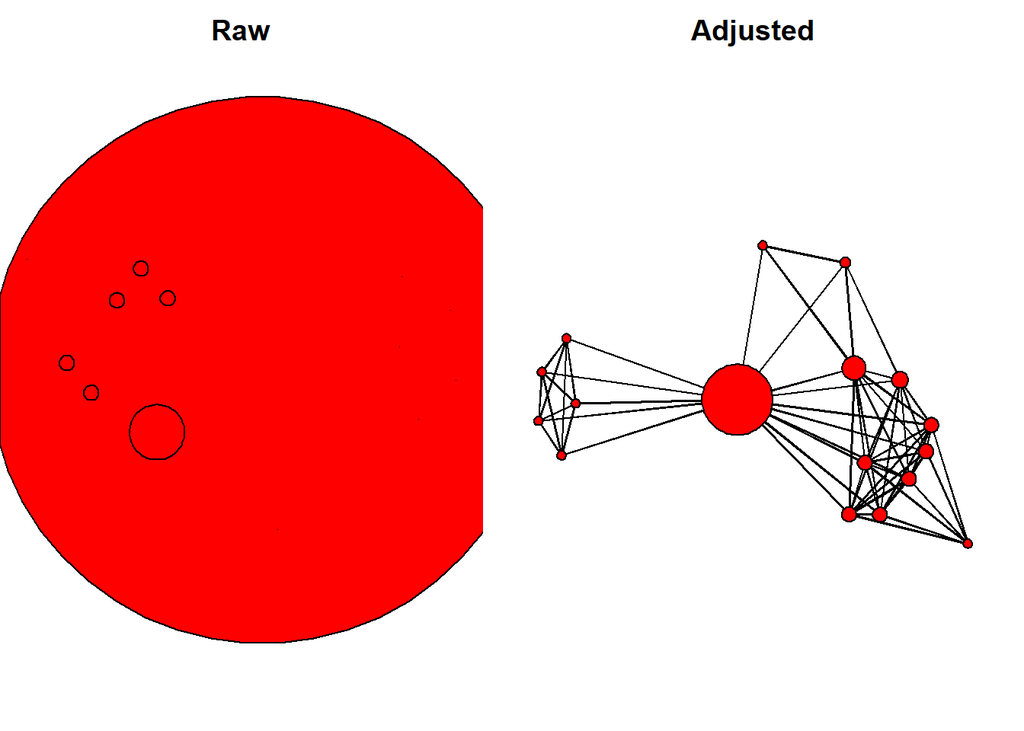

```r
par(op)

op <- par(mar = c(0,0,2,1),mfrow=c(1,2))
plot(Bali,usearrows=T,vertex.cex=bet,main="Raw")
plot(Bali,usearrows=FALSE,vertex.cex=sqrt(bet+1),main="Adjusted")
```

```r
par(op)
```

Aceste ajustari manuale pot fi obositoare. O functie utila pentru a ajusta valorile unui vector este urmatoarea:

```r
rescale <- function(nchar,low,high) {
  min_d <- min(nchar)
  max_d <- max(nchar)
  rscl <- ((high-low)*(nchar-min_d))/(max_d-min_d)+low
  rscl
}
```

Functia **rescale** primeste un vector de numere si valorile *low* si *high*. La final, fiecare numar se va gasi in intervalul [low,high].

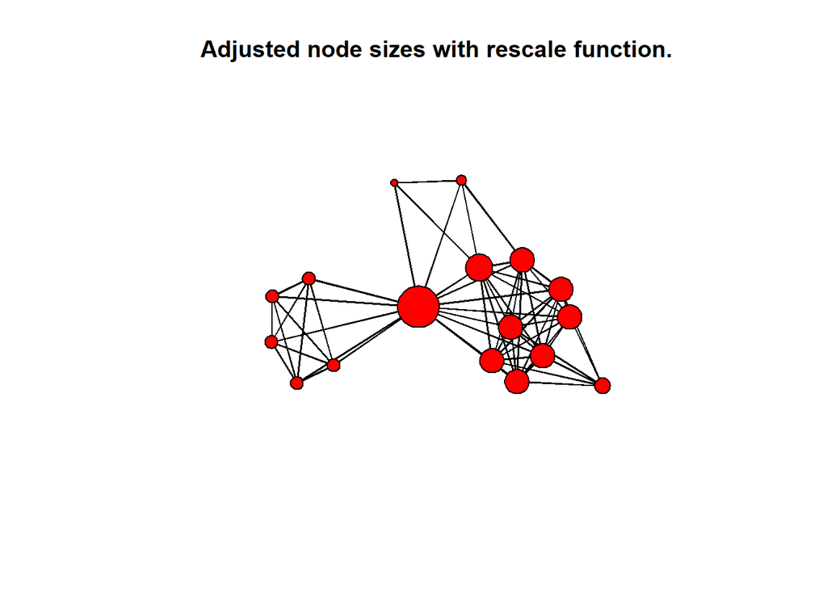

```r
plot(Bali,vertex.cex=rescale(deg,1,6),main="Adjusted node sizes with rescale function.")
```

### **Etichete ale nodurilor**

Un grafic este mai usor de inteles daca fiecare nod are o **eticheta asociata**. Totusi, daca numarul de noduri este prea mare, aceasta tehnica isi pierde eficienta si chiar dauneaza expresivitatii graficului.

Daca un obiect de tip retea din libraria *statnet* contine atributul *vertex.names* pentru noduri, acesta poate fi folosit pentru a afisa automat etichetele cand se ploteaza graficul. De asemenea, alte caracteristici ale etichetele pot fi controlate: marimea textului, culoarea, distanta fata de nodul asociat, etc.

```r
get.vertex.attribute(Bali,"vertex.names")
```

```
##  [1] "Muklas"   "Amrozi"   "Imron"    "Samudra"  "Dulmatin" "Idris"
##  [7] "Mubarok"  "Husin"    "Ghoni"    "Arnasan"  "Rauf"     "Octavia"
## [13] "Hidayat"  "Junaedi"  "Patek"    "Feri"     "Sarijo"
```

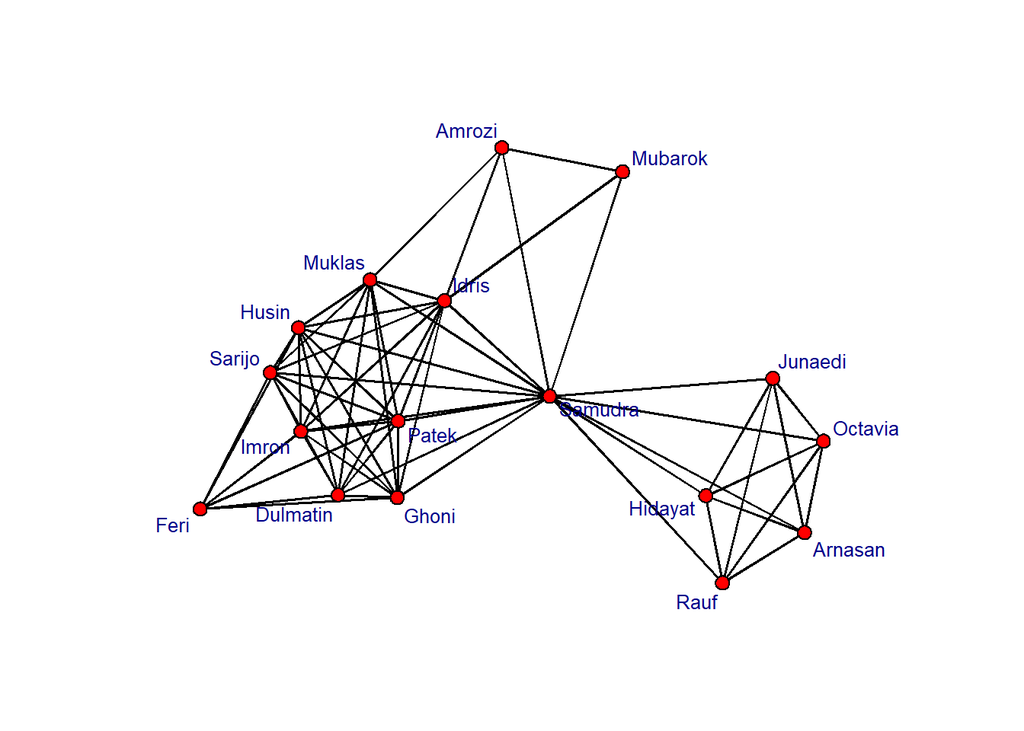

```r
op <- par(mar = c(0,0,0,0))
plot(Bali,displaylabels=TRUE,label.cex=0.8,pad=0.4,label.col="darkblue")
```

```r
par(op)
```

Valorile din vectorul *vertex.names* pot fi irelevante. Din fericire, putem folosi alt atribut pentru valorile etichetelor. In cazul retelei Bali, atributul *role* ofera mai multa informatie decat numele membrilor.

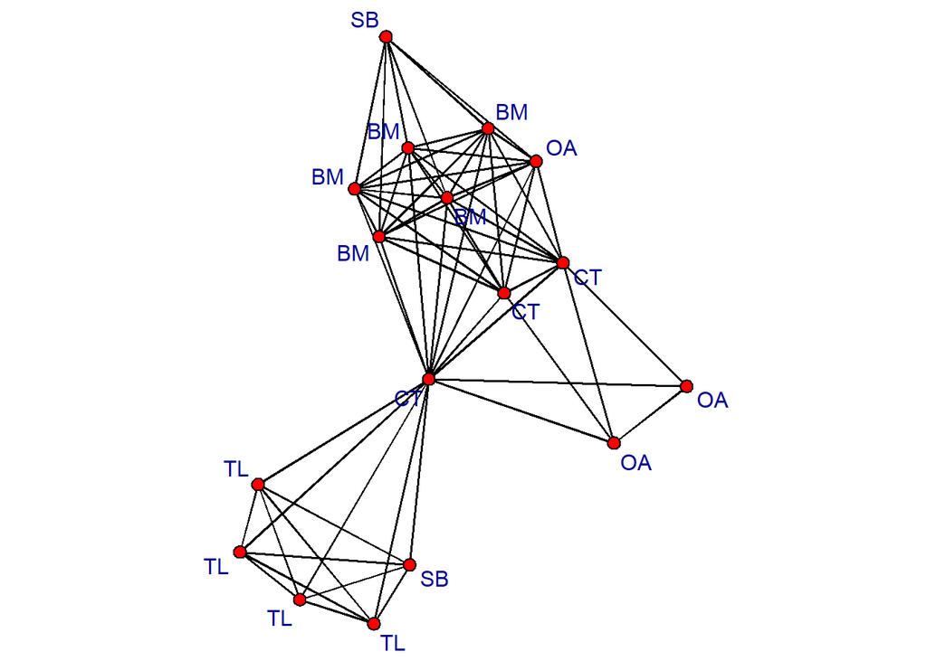

```r
op <- par(mar = c(0,0,0,0))
rolelab <- get.vertex.attribute(Bali,"role")
plot(Bali,usearrows=FALSE,label=rolelab,displaylabels=T,label.col="darkblue")
```

```r
par(op)
```

### **Grosimea muchiilor**

Daca reteaua contine legaturi care au asociate valori cantitative, atunci acestea pot fi reprezentate prin grosimea unei muchii. De exemplu, gradul de intensitate al unei prietenii, marimea sumei de bani dintr-o tranzactie financiara, sunt informatii care pot contribui la grosimea unei muchii.

Reteaua Bali contine un atribut pentru fiecare muchie, numit **IC**, care simbolizeaza gradul de interactiune dintre cei doi membri ai retelei. Muchiile mai groase reprezinta relatii mai puternice.

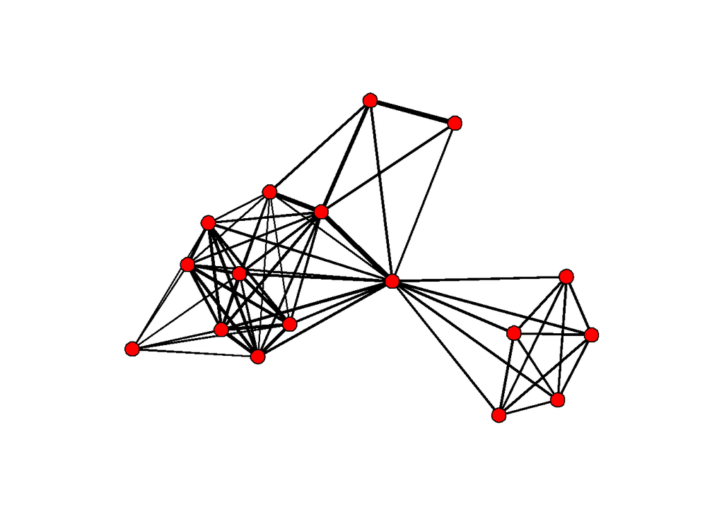

```r
op <- par(mar = c(0,0,0,0))
IClevel <- Bali %e% "IC"
plot(Bali,vertex.cex=1.5,edge.lwd=1.5*IClevel)
```

```r
par(op)
```

### **Culoarea muchiilor**

Spre deosebire de grosimea unei muchii, care transmite o valoare cantitativa, culoarea unei muchii comunica o valoare calitativa a legaturii dintre cele doua noduri. Spre exemplu, intr-o retea sociala, muchiile verzi pot insemna prietenii, muchiile gri neutralitate iar muchiile rosii dusmanii.

Reteaua Bali nu contine o valoare calitativa asociata muchiilor, asa ca vom crea noi una, pentru a oferi un exemplu.

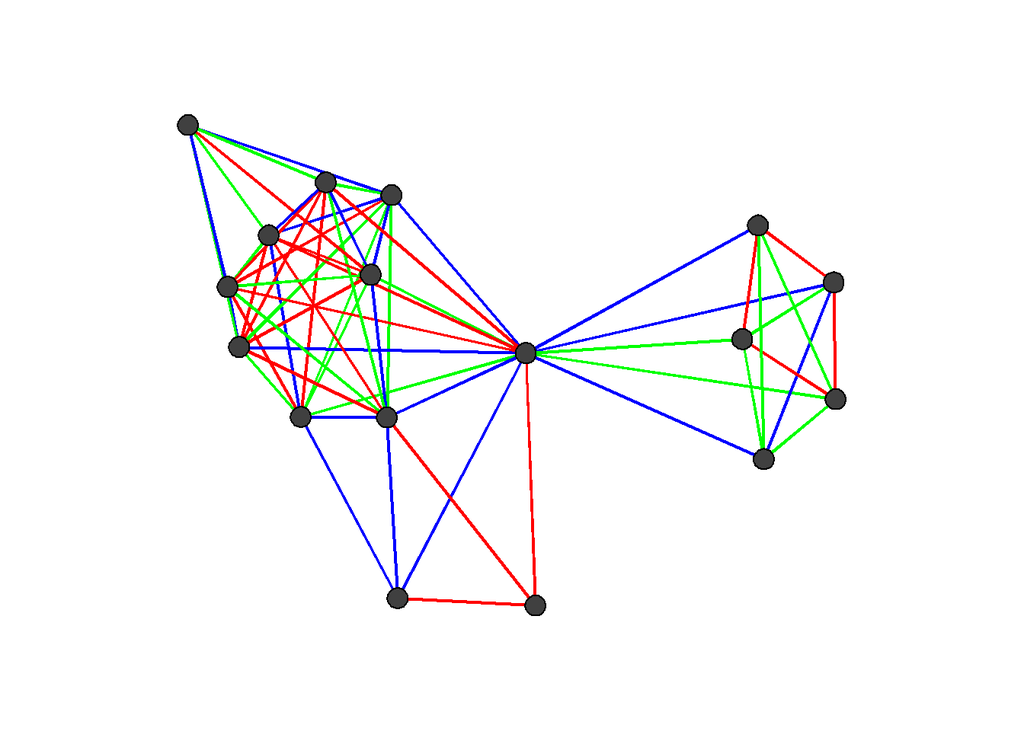

```r
op <- par(mar = c(0,0,0,0))

n_edge <- network.edgecount(Bali)
edge_cat <- sample(1:3,n_edge,replace=T)
linecol_pal <- c("blue","red","green")

plot(Bali,vertex.cex=1.5,vertex.col="grey25",
     edge.col=linecol_pal[edge_cat],
     edge.lwd=2)
```

```r
par(op)
```

### **Tipul muchiilor**

Asemanator culorii unei muchii, tipul acesteia poate comunica informatii calitative. Mergand pe acelasi exemplu, vom simula un atribut al muchiilor si vom plota folosind diferita tipuri de muchii (2-linie intrerupta; 3-linie punctata; 4-linie punctata si intrerupta).

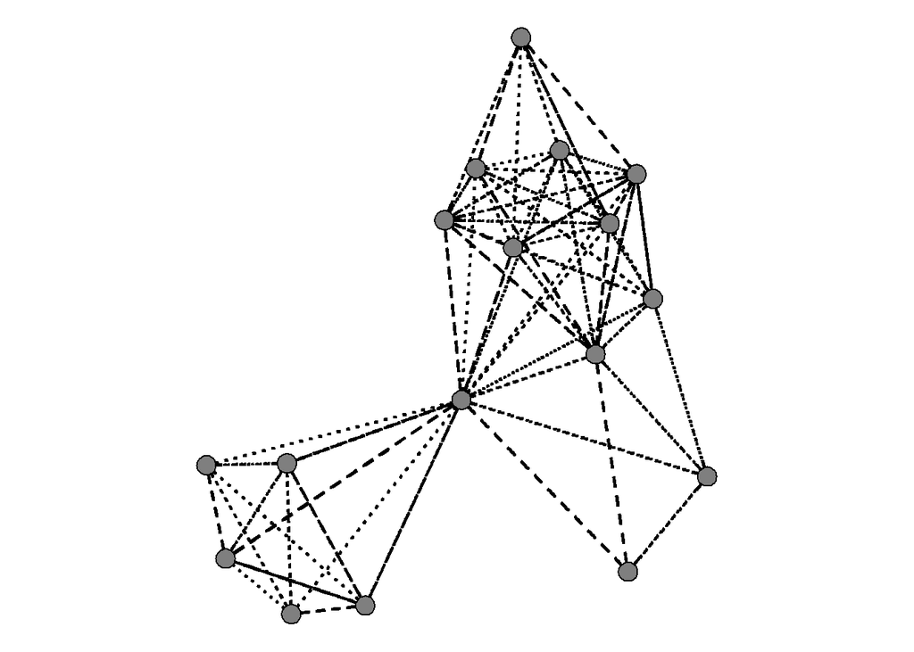

```r
op <- par(mar = c(0,0,0,0))

n_edge <- network.edgecount(Bali)
edge_cat <- sample(1:3,n_edge,replace=T)
line_pal <- c(2,3,4)

gplot(Bali,vertex.cex=0.8,gmode="graph",vertex.col="gray50",
      edge.lwd=1.5,
      edge.lty=line_pal[edge_cat])
```

```r
par(op)
```

Cu toate ca exemplul de mai sus functioneaza, nu este prea estetic. Folosirea unor tipuri diferite de muchii este recomandata doar pentru retele foarte mici, ce contin doar doua-trei tipuri de muchii.

### **Legende**

O legenda are rolul de a clarifica informatiile continute in grafic. Functiile de baza de plotare din *statnet* nu ofera aceasta functionalitate, dar putem folosi functia **legend()** din limbajul R.

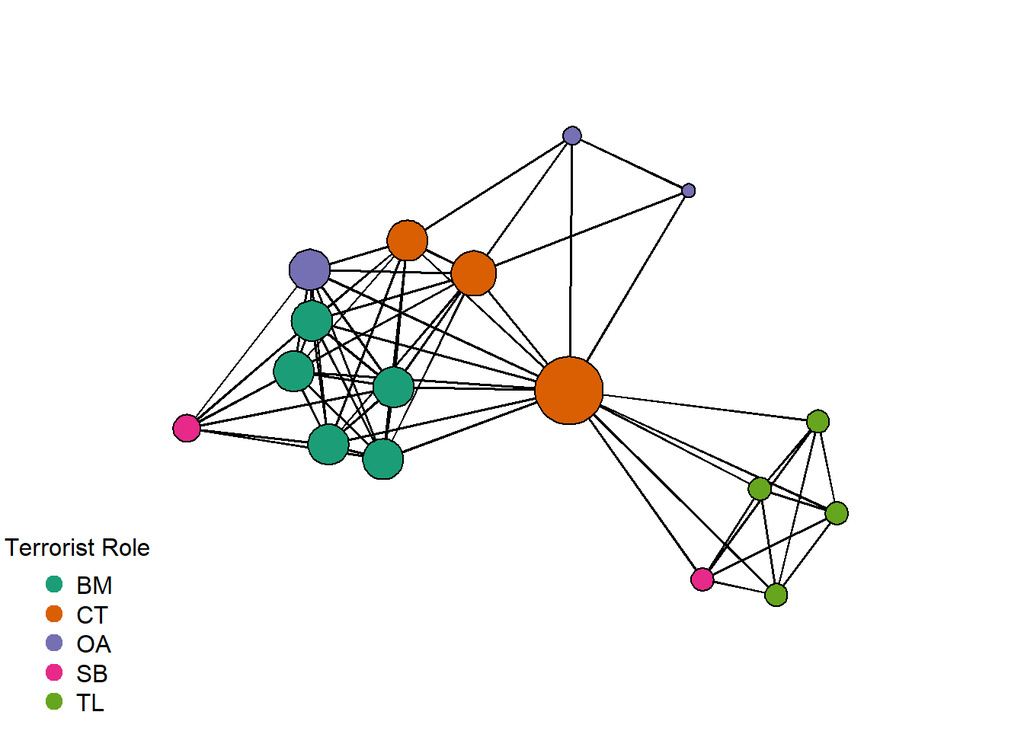

```r
op <- par(mar = c(0,0,0,0))

my_pal <- brewer.pal(5,"Dark2")
rolecat <- as.factor(get.vertex.attribute(Bali,"role"))

plot(Bali,vertex.cex=rescale(deg,1,5),vertex.col=my_pal[rolecat])

legend("bottomleft",
       legend=c("BM","CT","OA","SB","TL"),
       col=my_pal,
       pch=19,
       pt.cex=1.5,
       bty="n",
       title="Terrorist Role")
```

```r
par(op)
```